# Decision Tree to Solve The Mystery of Federalist Papers

Beverlyn Tucker

5/2/2020

##Introduction Three founding fathers, Alexander Hamilton, James Madison, and John Jay, significantly contributed to the ratification of the Constitution of the United States of America. In the papers they authored, The Federalist Papers, a consistent message was delivered in favor of signing the Constitution.

These founding fathers wrote the collection of 85 papers. However, 11 were disputed to have authorship of either Alexander Hamilton or James Madison. This controversy motivated many to perform various analyses. In a previous result, using kmeans clustering, it was found that the disputed authorship belonged to Alexander Hamilton. However, it was also noted in the result; the analysis was likely flawed. Instead of discretizing the author, the removal would have produced better clustering results.

In this study, decision trees will be used to verify whether previous results were accurate. This will be done by generating a train set using all papers except those of disputed authorship. Once a model is generated, a prediction will be made on the disputed authorship. Various error values and tuning methods will be attempted to verify the integrity of the decision trees.

```r
library(tidyverse)
library(caret)
```

```r
library(knitr)
library(rpart)
library(rpart.plot)
```

```r
dfed <- read_csv("D:/1. Syracuse/6.IST707_DATA_ANALYTICS/fedPapers85.csv")
head(dfed)
```

```
## # A tibble: 6 x 72
##   author filename     a   all  also    an   and   any   are    as    at    be
##   <chr>  <chr>    <dbl> <dbl> <dbl> <dbl> <dbl> <dbl> <dbl> <dbl> <dbl> <dbl>
## 1 dispt  dispt_f~ 0.28  0.052 0.009 0.096 0.358 0.026 0.131 0.122 0.017 0.411
## 2 dispt  dispt_f~ 0.177 0.063 0.013 0.038 0.393 0.063 0.051 0.139 0.114 0.393
## 3 dispt  dispt_f~ 0.339 0.09  0.008 0.03  0.301 0.008 0.068 0.203 0.023 0.474
## 4 dispt  dispt_f~ 0.27  0.024 0.016 0.024 0.262 0.056 0.064 0.111 0.056 0.365
## 5 dispt  dispt_f~ 0.303 0.054 0.027 0.034 0.404 0.04  0.128 0.148 0.013 0.344
## 6 dispt  dispt_f~ 0.245 0.059 0.007 0.067 0.282 0.052 0.111 0.252 0.015 0.297
## # ... with 60 more variables: been <dbl>, but <dbl>, by <dbl>, can <dbl>,
## #   do <dbl>, down <dbl>, even <dbl>, every <dbl>, `for` <dbl>, from <dbl>,
## #   had <dbl>, has <dbl>, have <dbl>, her <dbl>, his <dbl>, `if` <dbl>,
## #   `in` <dbl>, into <dbl>, is <dbl>, it <dbl>, its <dbl>, may <dbl>,
## #   more <dbl>, must <dbl>, my <dbl>, no <dbl>, not <dbl>, now <dbl>, of <dbl>,
## #   on <dbl>, one <dbl>, only <dbl>, or <dbl>, our <dbl>, shall <dbl>,
## #   should <dbl>, so <dbl>, some <dbl>, such <dbl>, than <dbl>, that <dbl>,
## #   the <dbl>, their <dbl>, then <dbl>, there <dbl>, things <dbl>, this <dbl>,
## #   to <dbl>, up <dbl>, upon <dbl>, was <dbl>, were <dbl>, what <dbl>,
## #   when <dbl>, which <dbl>, who <dbl>, will <dbl>, with <dbl>, would <dbl>,
## #   your <dbl>
```

```r
dfed = dfed[, -c(2)]
```

```r
test_keys = which(dfed$author == 'dispt')
```

```r
train_keys = which(dfed$author != 'dispt')

test_keys = which(dfed$author == 'dispt')
```

```r
train = dfed[train_keys, ]
head(train)
```

```
## # A tibble: 6 x 71
##   author     a   all  also    an   and   any   are    as    at    be  been   but
##   <chr>  <dbl> <dbl> <dbl> <dbl> <dbl> <dbl> <dbl> <dbl> <dbl> <dbl> <dbl> <dbl>
## 1 Hamil~ 0.213 0.083 0     0.083 0.343 0.056 0.111 0.093 0.065 0.315 0.028 0
## 2 Hamil~ 0.369 0.07  0.006 0.076 0.411 0.023 0.053 0.117 0.065 0.258 0.018 0.023
## 3 Hamil~ 0.305 0.047 0.007 0.068 0.386 0.047 0.102 0.108 0.088 0.271 0.054 0.041
## 4 Hamil~ 0.391 0.045 0.015 0.03  0.27  0.045 0.06  0.09  0.015 0.376 0.03  0.03
## 5 Hamil~ 0.327 0.096 0     0.086 0.356 0.014 0.086 0.072 0.115 0.211 0.067 0.034
## 6 Hamil~ 0.26  0.065 0     0.087 0.274 0.079 0.022 0.13  0.079 0.397 0.051 0.036
## # ... with 58 more variables: by <dbl>, can <dbl>, do <dbl>, down <dbl>,
## #   even <dbl>, every <dbl>, `for` <dbl>, from <dbl>, had <dbl>, has <dbl>,
## #   have <dbl>, her <dbl>, his <dbl>, `if` <dbl>, `in` <dbl>, into <dbl>,
## #   is <dbl>, it <dbl>, its <dbl>, may <dbl>, more <dbl>, must <dbl>, my <dbl>,
## #   no <dbl>, not <dbl>, now <dbl>, of <dbl>, on <dbl>, one <dbl>, only <dbl>,
## #   or <dbl>, our <dbl>, shall <dbl>, should <dbl>, so <dbl>, some <dbl>,
## #   such <dbl>, than <dbl>, that <dbl>, the <dbl>, their <dbl>, then <dbl>,
## #   there <dbl>, things <dbl>, this <dbl>, to <dbl>, up <dbl>, upon <dbl>,
## #   was <dbl>, were <dbl>, what <dbl>, when <dbl>, which <dbl>, who <dbl>,
## #   will <dbl>, with <dbl>, would <dbl>, your <dbl>
```

```r
test = dfed[test_keys, ]
head(test)
```

```
## # A tibble: 6 x 71
##   author     a   all  also    an   and   any   are    as    at    be  been   but
##   <chr>  <dbl> <dbl> <dbl> <dbl> <dbl> <dbl> <dbl> <dbl> <dbl> <dbl> <dbl> <dbl>
## 1 dispt  0.28  0.052 0.009 0.096 0.358 0.026 0.131 0.122 0.017 0.411 0.026 0.009
## 2 dispt  0.177 0.063 0.013 0.038 0.393 0.063 0.051 0.139 0.114 0.393 0.165 0
## 3 dispt  0.339 0.09  0.008 0.03  0.301 0.008 0.068 0.203 0.023 0.474 0.015 0.038
## 4 dispt  0.27  0.024 0.016 0.024 0.262 0.056 0.064 0.111 0.056 0.365 0.127 0.032
## 5 dispt  0.303 0.054 0.027 0.034 0.404 0.04  0.128 0.148 0.013 0.344 0.047 0.061
## 6 dispt  0.245 0.059 0.007 0.067 0.282 0.052 0.111 0.252 0.015 0.297 0.03  0.037
## # ... with 58 more variables: by <dbl>, can <dbl>, do <dbl>, down <dbl>,
## #   even <dbl>, every <dbl>, `for` <dbl>, from <dbl>, had <dbl>, has <dbl>,
## #   have <dbl>, her <dbl>, his <dbl>, `if` <dbl>, `in` <dbl>, into <dbl>,
## #   is <dbl>, it <dbl>, its <dbl>, may <dbl>, more <dbl>, must <dbl>, my <dbl>,
## #   no <dbl>, not <dbl>, now <dbl>, of <dbl>, on <dbl>, one <dbl>, only <dbl>,
## #   or <dbl>, our <dbl>, shall <dbl>, should <dbl>, so <dbl>, some <dbl>,
## #   such <dbl>, than <dbl>, that <dbl>, the <dbl>, their <dbl>, then <dbl>,
## #   there <dbl>, things <dbl>, this <dbl>, to <dbl>, up <dbl>, upon <dbl>,
## #   was <dbl>, were <dbl>, what <dbl>, when <dbl>, which <dbl>, who <dbl>,
## #   will <dbl>, with <dbl>, would <dbl>, your <dbl>
```

```r
fit.default = rpart(

  author ~ .,

  data = train,

  method = 'class'

)
head(fit.default)
```

[output not shown]

[output cut: 415 more lines]

[output not shown]

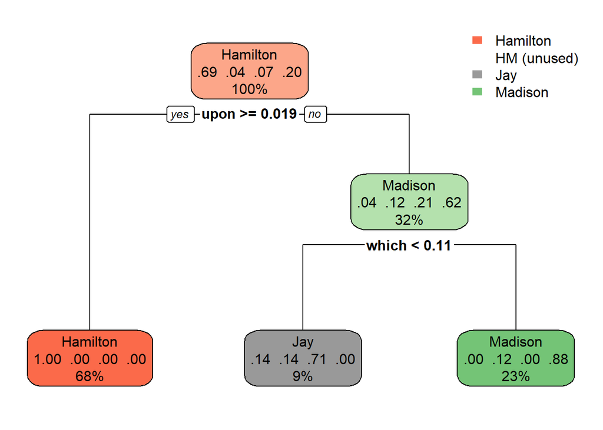

```r
rpart.plot(fit.default)
```

```r
printcp(fit.default)
```

```
##
## Classification tree:
## rpart(formula = author ~ ., data = train, method = "class")
##
## Variables actually used in tree construction:
## [1] upon  which
##
## Root node error: 23/74 = 0.31081
##
## n= 74
##
##        CP nsplit rel error  xerror    xstd
## 1 0.60870      0   1.00000 1.00000 0.17310
## 2 0.21739      1   0.39130 0.43478 0.12786
## 3 0.01000      2   0.17391 0.52174 0.13786
```

```r
fit.default.pred = table(predict(fit.default, type='class'), train$author)

1-sum(diag(fit.default.pred))/sum(fit.default.pred)
```

```
## [1] 0.05405405
```

```r
predict(fit.default, test, type = 'prob')
```

```
##     Hamilton        HM       Jay   Madison
## 1  0.0000000 0.1176471 0.0000000 0.8823529
## 2  0.0000000 0.1176471 0.0000000 0.8823529
## 3  0.1428571 0.1428571 0.7142857 0.0000000
## 4  0.0000000 0.1176471 0.0000000 0.8823529
## 5  0.0000000 0.1176471 0.0000000 0.8823529
## 6  0.0000000 0.1176471 0.0000000 0.8823529
## 7  0.0000000 0.1176471 0.0000000 0.8823529
## 8  0.0000000 0.1176471 0.0000000 0.8823529
## 9  0.0000000 0.1176471 0.0000000 0.8823529
## 10 0.0000000 0.1176471 0.0000000 0.8823529
## 11 0.0000000 0.1176471 0.0000000 0.8823529
```

##Data showed Jay wrote the third paper.

```r
predict(fit.default, test, type = 'class')
```

```
##       1       2       3       4       5       6       7       8       9      10
## Madison Madison     Jay Madison Madison Madison Madison Madison Madison Madison
##      11
## Madison
## Levels: Hamilton HM Jay Madison
```

## @maxdepth, john jay has 5 articles, indicated by the default tree

on the second level. Using one level elminates the ‘john jay’

```r
fit.tuned = rpart(

  author ~ .,

  data = train,

  method = 'class',

  control = list(maxdepth = 1)
)
```

## maxdepth = 1

To tune the parameter to reduce tree levels to one allowing the outlier to be removed, this will allow the model to distinguish between James Madison and Alexander Hamilton.

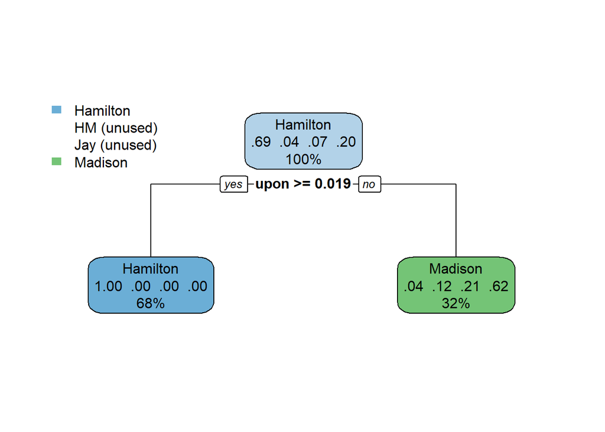

```r
rpart.plot(fit.tuned)
```

```r
printcp(fit.tuned)
```

```
##
## Classification tree:
## rpart(formula = author ~ ., data = train, method = "class", control = list(maxdepth = 1))
##
## Variables actually used in tree construction:
## [1] upon
##
## Root node error: 23/74 = 0.31081
##
## n= 74
##
##       CP nsplit rel error  xerror    xstd
## 1 0.6087      0    1.0000 1.00000 0.17310
## 2 0.0100      1    0.3913 0.43478 0.12786
```

## tuned tree summary

```r
printcp(fit.tuned)
```

```
##
## Classification tree:
## rpart(formula = author ~ ., data = train, method = "class", control = list(maxdepth = 1))
##
## Variables actually used in tree construction:
## [1] upon
##
## Root node error: 23/74 = 0.31081
##
## n= 74
##
##       CP nsplit rel error  xerror    xstd
## 1 0.6087      0    1.0000 1.00000 0.17310
## 2 0.0100      1    0.3913 0.43478 0.12786
```

##Result Root node error is 0.31081 To measure the error rate

```r
##Determine the predictive performance
fit.tuned.pred = table(predict(fit.tuned, type='class'), train$author)

1-sum(diag(fit.tuned.pred))/sum(fit.tuned.pred)
```

```
## [1] 0.1216216
```

```r
fit.tuned.pred
```

```
##
##            Hamilton HM Jay Madison
##   Hamilton       50  0   0       0
##   HM              0  0   0       0
##   Jay             0  0   0       0
##   Madison         1  3   5      15
```

## Cross Validation

```r
xpred.rpart(fit.tuned, xval=10)
```

```
##    0.80434783 0.07801895
## 1           1          1
## 2           1          1
## 3           1          1
## 4           1          1
## 5           1          1
## 6           1          1
## 7           1          1
## 8           1          1
## 9           1          1
## 10          1          1
## 11          1          1
## 12          1          4
## 13          1          1
## 14          1          1
```

[output cut: 60 more lines]

```r
predict(fit.tuned, test, type = 'prob')
```

```
##      Hamilton    HM       Jay Madison
## 1  0.04166667 0.125 0.2083333   0.625
## 2  0.04166667 0.125 0.2083333   0.625
## 3  0.04166667 0.125 0.2083333   0.625
## 4  0.04166667 0.125 0.2083333   0.625
## 5  0.04166667 0.125 0.2083333   0.625
## 6  0.04166667 0.125 0.2083333   0.625
## 7  0.04166667 0.125 0.2083333   0.625
## 8  0.04166667 0.125 0.2083333   0.625
## 9  0.04166667 0.125 0.2083333   0.625
## 10 0.04166667 0.125 0.2083333   0.625
## 11 0.04166667 0.125 0.2083333   0.625
```

## Result on Disputed Papers

Base on the decision tree, most of the disputed papers indicates that owned by James Madison.

```r
predict(fit.tuned, test, type = 'class')
```

```
##       1       2       3       4       5       6       7       8       9      10
## Madison Madison Madison Madison Madison Madison Madison Madison Madison Madison
##      11
## Madison
## Levels: Hamilton HM Jay Madison
```

##Conclusion From this analysis, it has been found that the disputed authorship appears more closely related to James Madison, then Alexander Hamilton. These results are quite contrary to the previous finding. However, as indicated in this study, implementing proper train and test sets would have provided additional error measures for the corresponding decision tree models. But, due to the relatively small dataset size, further splitting the provided dataset into a train and test set, would have reduced the already small dataset for training a model. This could likely increase the chances of overfitting.

As mentioned in a previous study, obtaining additional works produced by James Madison, to complement the initial dataset, would have produced a richer context to work. The same case for obtaining more writing samples for Alexander Hamilton would be valid. The best steps forward for both studies could likely be an integration of more data, as well as an adjustment to each preprocessing step.